# ECO232 R で始めるデータサインエス課題：応答

Hiroshi Suzuki（鈴木寛）

2023-02-26

# 1 はじめに

まずは、謝るところから始めないといけません。テンプレートをそのまま、使うと、エラーが出てしまいます。問題なかったかたもおられると思いますが、それは、今回の授業の作業をしたプロジェイウトに続けて、作業をしたからだと思われます。スクリプトの中で、`wdi_cache` をもう一度読み込むことを忘れていました。それが、どこに保存されているかも確認していなかったので、テンプレートには、最初の、setup と書いてある、コードチャンクの次に、`wdi_cache <- WDIcache()` をしておかないといけませんでした。それを追加した上で、コメントを書きます。

気づいて、しっかり読み込んでくださった方もおられました。申し訳ありません。

まだ、`data` フォルダを作成していなければ、次のコード・チャンクを実行します。作成してあれば不要です。

```r
dir.create("./data")
```

次も、もし、`data` フォルダーに、`wdi_cache.RData` が入っていれば実行する必要はありません。

```r
wdi_cache <- WDIcache()
write_rds(wdi_cache, "./data/wdi_cache.RData")
```

おそらく、すでに、`wdi_cache.RData` は、`data` フォルダにあると思うのでこの下のコードだけで十分なはずです。

```r
wdi_cache <- read_rds("./data/wdi_cache.RData")
```

本来は、皆さんが課題で取り組んでくださったことに対して、しっかりと応答を書くべきところですが、しばらく、時間が取れないので、皆さんが、調べてくださった、WDI コードのリストだけ、書いておきたいと思います。ひょっとすると、漏れているものもあるかと思いますが、それは、お許しください。最初のリストは、コピー・ペーストをしたので、見落とした可能性は大です。しかし、他のクラスメートがどんな指標について調べたのかを知ることは、勉強になると思います。

実は、わたし自身、非常に感銘を受けました。流石に、中級マクロの受講生ですね。調べたい、インディケータをたくさん持っておられる。それを、わたしも確認したいということも、このリストを作った、目的です。

最初のリストを作ってから、やはり、WDI Name と言われる名前や、概要などの情報も欲しいですよね。それをつけたものを、下で作成しています。今回は、そこまでとして、応答は、また時間があればとさせてください。

実は、テンプレートからコピーをするときに、最初の行が落ちているために、Preview ができていなかった人。Notebook ではなく、R Markdown から、HTML を作ったために、コードをみることができなかったもの。

また、OECD などから、データを取ってきて調べてくださった方もおられましたが、そのサイトの URL が書いてなかったので、わたしは、探せなかったものなどもありました。

まあ、それも、練習ですし、今回が最初ですから、そのようなことが起こることは、織り込み済みですから、気にしないでください。少しずつ、質が上がると良いですね。最初の始めてみようには、R Markdown の説明もビデオとともに付けてあります。

そのようなものも見てみると良いでしょう。

海蔵寺先生も言っておられましたが、基本は、

> 身近なデータを取ってきて図にする。一連の作業を文書化する。

だと、思っています。Posit Primers も最初は、Visualization から始めています。わたしも、それがよいと思っています。そして、再現性 (Reproducibility) と、コードチャンクで実行していることを、説明していく、Literate Programming のためのものが、この RNotebook です。再現性は、とても、大切です。自分のためにも。特に、データをどのように取得するかは、丁寧に、書いておいてください。WDI の場合は、コードだけで十分ですが、本来は、取得した日にちも必要です。ただ、それは、上の、Date のところに書いてあり、自動的に、更新されます。

少しずつ進んでいっていただけると嬉しいです。

## 1.1 みなさんが、選んでくださった、WDI コード

```r
url_indicators <- "https://ds-sl.github.io/intro2r/data/indicators.csv"
df_indicators <- read_csv(url_indicators) %>% left_join(wdi_cache$series)
write_csv(df_indicators, "./data/indicators.csv")
df_indicators
```

| indicator | name | description | sourceDatabase | sourceOrganization |
| --- | --- | --- | --- | --- |
| 1.0.HCount.Mid10to50 | Middle Class ($10-50 a day) Headcount | The poverty headcount index measures the proportion of the population with daily per capita income (in 2005 PPP) below the poverty line. | LAC Equity Lab | LAC Equity Lab tabulations of SEDLAC (CEDLAS and the World Bank). |
| 2.0.cov.Int | Coverage: Internet | The coverage rate is the childhood access rate of a given opportunity used in calculating the Human Opportunities Index (HOI). The coverage rate does not take into account inequality of access between… | LAC Equity Lab | LAC Equity Lab tabulations of SEDLAC (CEDLAS and the World Bank). |
| 2.1_SHARE.TOTAL.RE.IN.TFEC | Renewable energy consumption(% in TFEC) | Renewable energy consumption(% in TFEC): Share of renewables energy in total final energy consumption | Sustainable Energy for All | World Bank and International Energy Agency (IEA Statistics © OECD/IEA, http://www.iea.org/stats/index.asp). |
| 3.0.Gini | Gini Coefficient | The Gini coefficient is most common measure of inequality. It is based on the Lorenz curve, a cumulative frequency curve that compares the distribution of a specific variable (in this case, income) wi… | LAC Equity Lab | LAC Equity Lab tabulations of SEDLAC (CEDLAS and the World Bank). |
| 3.0.Gini_nozero | Gini Coefficient (No Zero Income) | The Gini coefficient is most common measure of inequality. It is based on the Lorenz curve, a cumulative frequency curve that compares the distribution of a specific variable (in this case, income) wi… | LAC Equity Lab | LAC Equity Lab tabulations of SEDLAC (CEDLAS and the World Bank). |
| 4.1.studwork.15a18 | Youth: In School and Employed (15-18), Male | Share of the male population ages 15-18 that is in school and employed. | LAC Equity Lab | LAC Equity Lab tabulations of SEDLAC (CEDLAS and the World Bank), based on "Out of School and Out of Work: A Diagnostic of Ninis in Latin America" by De Hoyos, Popova, and Rogers (2014, World Bank). |
| 4.1.work.15a18 | Youth: Employed (15-18), Male | Share of the male population ages 15-18 that is employed and not in school. | LAC Equity Lab | LAC Equity Lab tabulations of SEDLAC (CEDLAS and the World Bank), based on "Out of School and Out of Work: A Diagnostic of Ninis in Latin America" by De Hoyos, Popova, and Rogers (2014, World Bank). |
| 4.2.work.15a18 | Youth: Employed (15-18), Female | Share of the female population ages 15-18 that is employed and not in school. | LAC Equity Lab | LAC Equity Lab tabulations of SEDLAC (CEDLAS and the World Bank), based on "Out of School and Out of Work: A Diagnostic of Ninis in Latin America" by De Hoyos, Popova, and Rogers (2014, World Bank). |
| 5.0.AMeanIncGr.All | Annualized Mean Income Growth (2004-2014) | The official indicator to monitor shared prosperity is the growth in real per capita income (or consumption) of the bottom 40 percent of the income (or consumption) distribution in a country. | LAC Equity Lab | LAC Equity Lab tabulations of SEDLAC (CEDLAS and the World Bank) and World Development Indicators |
| 6.0.GDP_current | GDP (current $) | GDP is the sum of gross value added by all resident producers in the economy plus any product taxes and minus any subsidies not included in the value of the products. It is calculated without making d… | LAC Equity Lab | World Development Indicators (World Bank) |

[output cut: 79 more lines]

下のコードを実行してもみることができます。

```r
View(df_indicators)
```

この続きは、いずれ時間があればと、させてください。

# 2 課題 1 - Assignment 1

下に４種類、６個のテンプレートがあります。指標 `indicator` と、略称 `short_name` と、いくつかの国名 `chosen_countries` を、入れ替えて、試してみてください。 コピー・ペーストしてもっと増やしても構いません。最低４種類、４個。テンプレートと同じものは不可。

## テンプレート Templates

## 2.1 一つの国についての、一つの指標（WDI）と、その略称から、折線グラフ

Line Plot with one indicator with abbreviation and one country

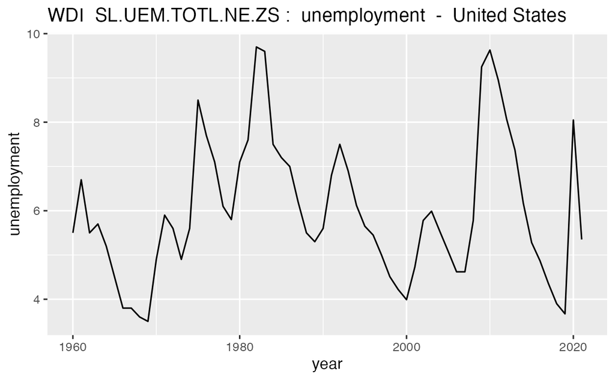

```r
chosen_indicator <- "SL.UEM.TOTL.NE.ZS"
short_name <- "unemployment"
chosen_country <- "United States"
WDI(country = "all", indicator = c(short_name = chosen_indicator), extra=TRUE, cache=wdi_cache) %>%
  filter(country == chosen_country) %>%
  ggplot(aes(year, short_name)) + geom_line() +
  labs(title = paste("WDI ", chosen_indicator, ": ", short_name, " - ", chosen_country),
       y = short_name)
```

## 2.2 いくつかの国についての、一つの指標（WDI）と、その略称から、折線グラフ

Line Plot with one indicator with abbreviation and several countries

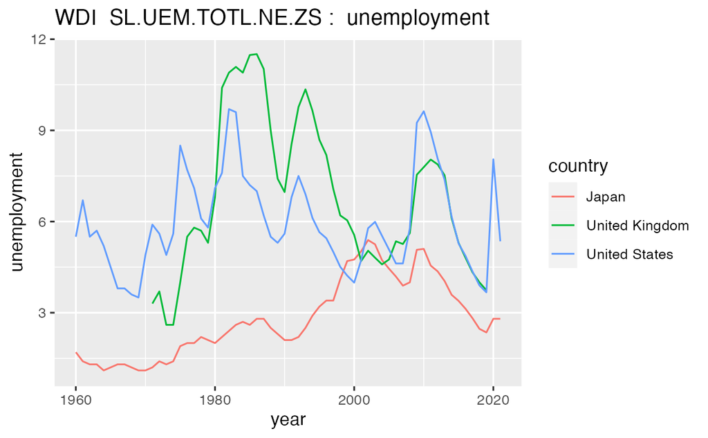

```r
chosen_indicator <- "SL.UEM.TOTL.NE.ZS"
short_name <- "unemployment"
chosen_countries <- c("United States","United Kingdom", "Japan")
WDI(country = "all", indicator = c(short_name = chosen_indicator), extra=TRUE, cache=wdi_cache) %>% drop_na(short_name) %>%
  filter(country %in% chosen_countries) %>%
  ggplot(aes(year, short_name, col = country)) + geom_line() +
  labs(title = paste("WDI ", chosen_indicator, ": ", short_name), y = short_name)
```

## 2.3 一つの国についての、二つの指標（WDI）と、その略称から、折線グラフ

Line Plot with two indicators with abbreviation and one country

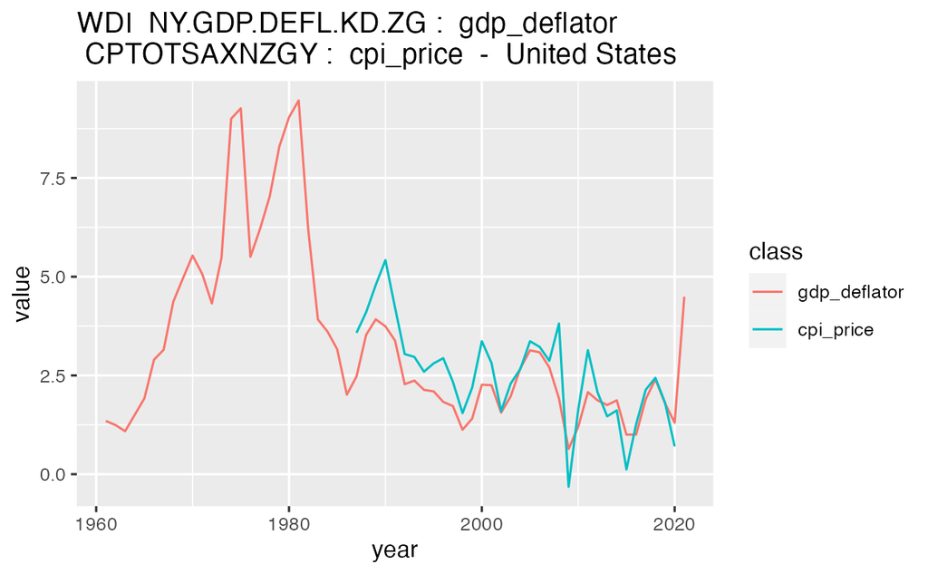

```r
chosen_indicator_1 <- "NY.GDP.DEFL.KD.ZG"
short_name_1 <- "gdp_deflator"
chosen_indicator_2 <- "CPTOTSAXNZGY"
short_name_2 <- "cpi_price"
chosen_country <- "United States"
WDI(country = "all", indicator = c(short_name_1 = chosen_indicator_1, short_name_2 = chosen_indicator_2), extra=TRUE, cache=wdi_cache) %>%
  filter(country == chosen_country) %>%
  pivot_longer(c(short_name_1, short_name_2), names_to = "class", values_to = "value") %>% drop_na(value) %>%
  ggplot(aes(year, value, col = class)) + geom_line() +
  labs(title = paste("WDI ", chosen_indicator_1, ": ", short_name_1, "\n", chosen_indicator_2, ": ", short_name_2, " - ", chosen_country)) +
  scale_color_manual(labels = c(short_name_1, short_name_2), values = scales::hue_pal()(2))
```

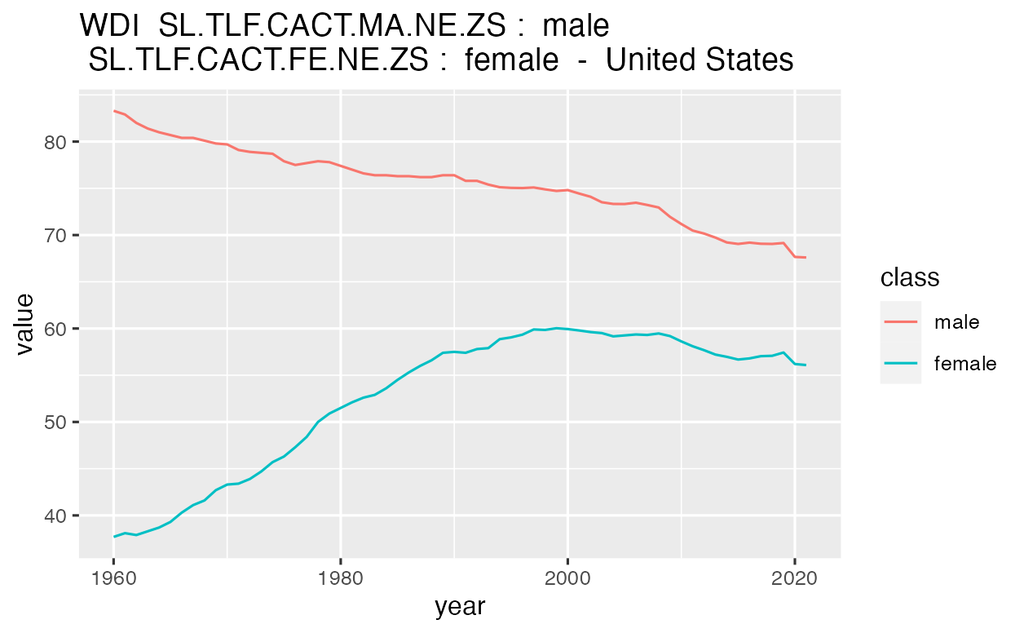

```r
chosen_indicator_1 <- "SL.TLF.CACT.MA.NE.ZS"
short_name_1 <- "male"
chosen_indicator_2 <- "SL.TLF.CACT.FE.NE.ZS"
short_name_2 <- "female"
chosen_country <- "United States"
WDI(country = "all", indicator = c(short_name_1 = chosen_indicator_1, short_name_2 = chosen_indicator_2), extra=TRUE, cache=wdi_cache) %>%
  filter(country == chosen_country) %>%
  pivot_longer(c(short_name_1, short_name_2), names_to = "class", values_to = "value") %>% drop_na(value) %>%
  ggplot(aes(year, value, col = class)) + geom_line() +
  labs(title = paste("WDI ", chosen_indicator_1, ": ", short_name_1, "\n", chosen_indicator_2, ": ", short_name_2, " - ", chosen_country)) +
  scale_color_manual(labels = c(short_name_1, short_name_2), values = scales::hue_pal()(2))
```

## 2.4 いくつかの国についての、二つの指標（WDI）と、その略称から、折線グラフ

Line Plot with two indicators with abbreviation and several countries

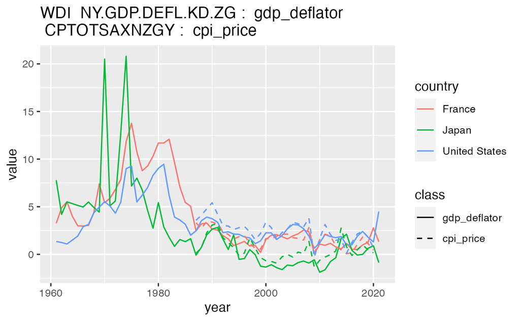

```r
chosen_indicator_1 <- "NY.GDP.DEFL.KD.ZG"
short_name_1 <- "gdp_deflator"
chosen_indicator_2 <- "CPTOTSAXNZGY"
short_name_2 <- "cpi_price"
chosen_countries <- c("United States", "France", "Japan")
WDI(country = "all", indicator = c(short_name_1 = chosen_indicator_1, short_name_2 = chosen_indicator_2), extra=TRUE, cache=wdi_cache) %>%
  filter(country %in% chosen_countries) %>%
  pivot_longer(c(short_name_1, short_name_2), names_to = "class", values_to = "value") %>% drop_na(value) %>%
  ggplot(aes(year, value, linetype = class, col = country)) + geom_line() +
  labs(title = paste("WDI ", chosen_indicator_1, ": ", short_name_1, "\n", chosen_indicator_2, ": ", short_name_2)) +
  scale_linetype_manual(labels = c(short_name_1, short_name_2), values = c("solid", "dashed"))
```

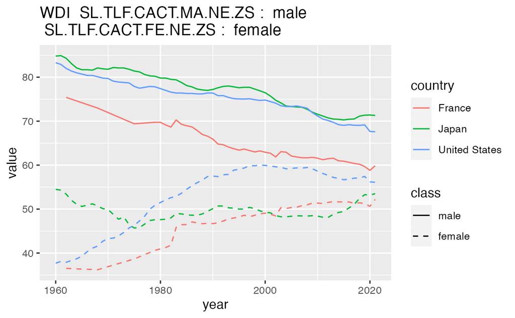

```r
chosen_indicator_1 <- "SL.TLF.CACT.MA.NE.ZS"
short_name_1 <- "male"
chosen_indicator_2 <- "SL.TLF.CACT.FE.NE.ZS"
short_name_2 <- "female"
chosen_countries <- c("United States", "France", "Japan")
WDI(country = "all", indicator = c(short_name_1 = chosen_indicator_1, short_name_2 = chosen_indicator_2), extra=TRUE, cache=wdi_cache) %>%
  filter(country %in% chosen_countries) %>%
  pivot_longer(c(short_name_1, short_name_2), names_to = "class", values_to = "value") %>% drop_na(value) %>%
  ggplot(aes(year, value, linetype = class, col = country)) + geom_line() +
  labs(title = paste("WDI ", chosen_indicator_1, ": ", short_name_1, "\n", chosen_indicator_2, ": ", short_name_2)) +
  scale_linetype_manual(labels = c(short_name_1, short_name_2), values = c("solid", "dashed"))
```

# 3 課題 2 - Assignment 2

探索的データ解析を経験してみよう。

1. 興味のあるデータ（または関連するいくつかのデータ）を見つける。
- [重要] なぜ、そのデータに興味を持ったか。
- WDI や、OECD や、UN Data。
- 課題1 と同じものでも構いません。しかし、選んだ理由を書くこと。
2. データを読み込む。
3. [重要] データに関する問い。
4. [重要] 可能な範囲で、データの可視化をして、得られたこと。
5. 難しかったこと、できなかったこと。

課題 1 と 課題 2 を、課題 テンプレートを用いて、書き、ID.nb.html ファイル を、2月24日（土）深夜までに Moodle 上に提出。